# PQHS 471 HW1

Youjun Li

April 09, 2018

# ISLR Chapter 7

## 9

### a

```r
library(MASS)
data("Boston")
fit=lm(nox~poly(dis, 3), Boston)
summary(fit)
```

```
##
## Call:
## lm(formula = nox ~ poly(dis, 3), data = Boston)
##
## Residuals:
##       Min        1Q    Median        3Q       Max
## -0.121130 -0.040619 -0.009738  0.023385  0.194904
##
## Coefficients:
##                Estimate Std. Error t value
## (Intercept)    0.554695   0.002759 201.021
## poly(dis, 3)1 -2.003096   0.062071 -32.271
## poly(dis, 3)2  0.856330   0.062071  13.796
## poly(dis, 3)3 -0.318049   0.062071  -5.124
##               Pr(>|t|)
## (Intercept)    < 2e-16 ***
## poly(dis, 3)1  < 2e-16 ***
## poly(dis, 3)2  < 2e-16 ***
## poly(dis, 3)3 4.27e-07 ***
## ---
## Signif. codes:
## 0 '***' 0.001 '**' 0.01 '*' 0.05 '.' 0.1 ' ' 1
##
## Residual standard error: 0.06207 on 502 degrees of freedom
## Multiple R-squared:  0.7148, Adjusted R-squared:  0.7131
## F-statistic: 419.3 on 3 and 502 DF,  p-value: < 2.2e-16
```

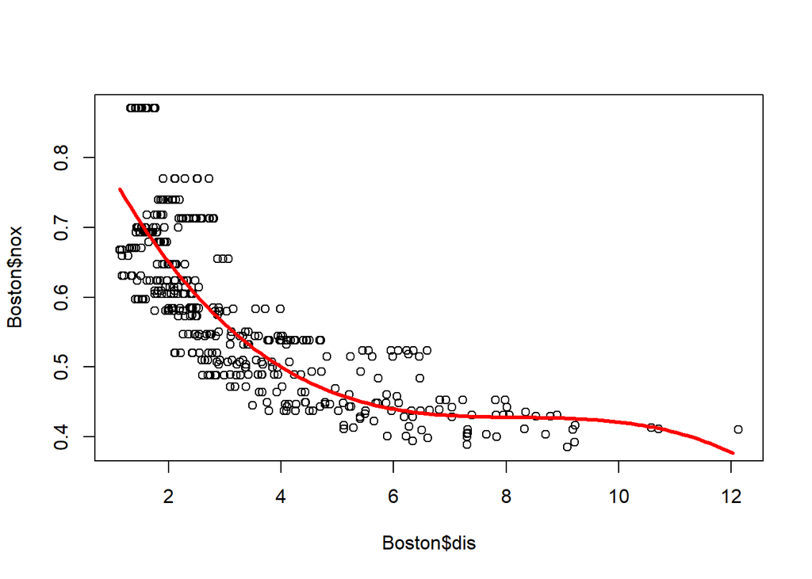

```r
newdis=seq(min(Boston$dis),max(Boston$dis),0.1)
plot(Boston$dis, Boston$nox)
lines(newdis, predict(fit, newdata = list(dis=newdis)), col='red', lwd=3)
```

### b

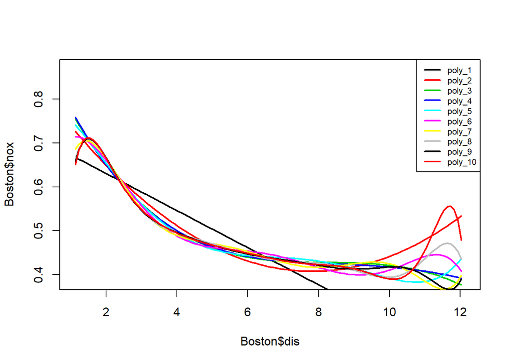

```r
library(boot)
f=list()
rss=c()
lgd=c()
plot(Boston$dis,Boston$nox, col='white')
for (i in 1:10)
{
  f[[i]]=glm(nox~poly(dis,i), data=Boston)
  rss[i]=sum(f[[i]]$residuals^2)
  lines(newdis, predict(f[[i]], newdata = list(dis=newdis)),lwd=2, col=i)
  lgd[i]=paste("poly",i,sep="_")
}
legend('topright', lgd[1:10], lwd=rep(2,10), col = c(1:10), cex=0.7)
```

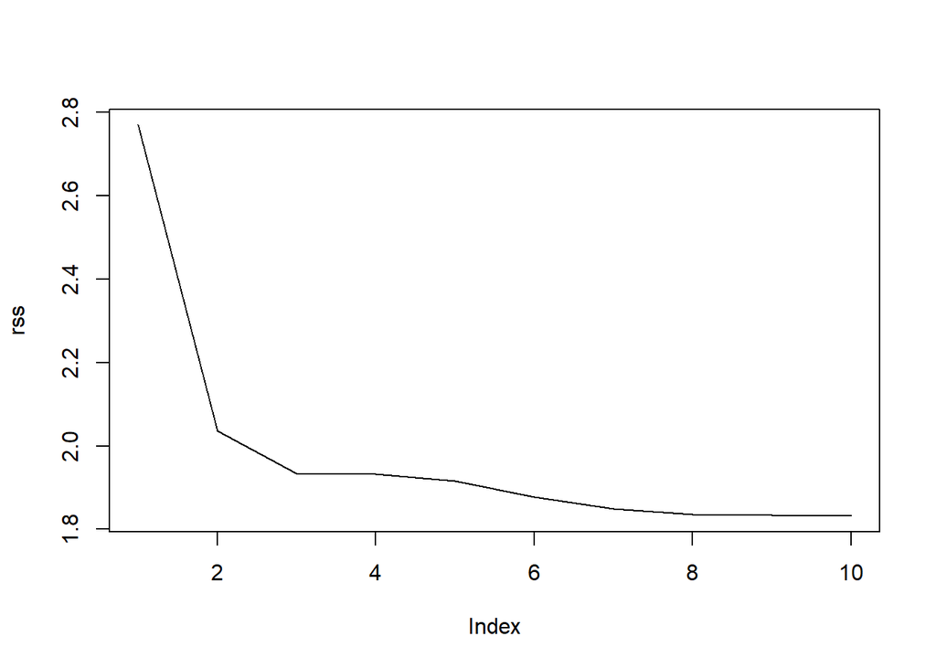

```r
plot(rss, type = 'l')
```

### c

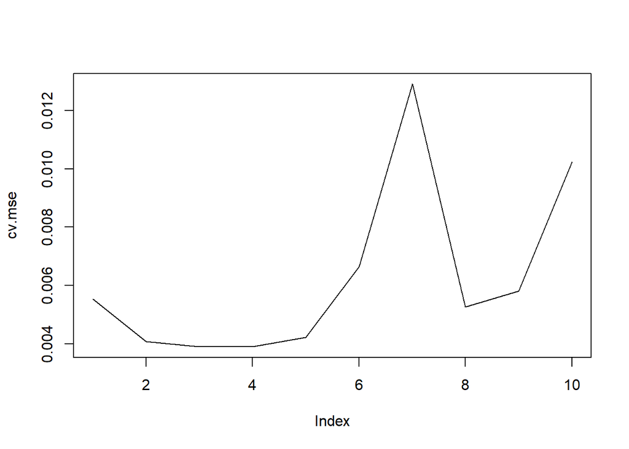

```r
set.seed(621)
cv.mse=c()
for (i in 1:10)
{
  cv.mse[i]=cv.glm(Boston, f[[i]], K=10)$delta[1]
}
plot(cv.mse,type = 'l')
```

```r
match(min(cv.mse), cv.mse)
```

```
## [1] 3
```

According to the cross-validation $MSE$, we end up with $degree=3$.

### d

```r
library(splines)
fit1=lm(nox~bs(dis, df=4), data = Boston)
summary(fit1)
```

```
##
## Call:
## lm(formula = nox ~ bs(dis, df = 4), data = Boston)
##
## Residuals:
##       Min        1Q    Median        3Q       Max
## -0.124622 -0.039259 -0.008514  0.020850  0.193891
##
## Coefficients:
##                  Estimate Std. Error t value
## (Intercept)       0.73447    0.01460  50.306
## bs(dis, df = 4)1 -0.05810    0.02186  -2.658
## bs(dis, df = 4)2 -0.46356    0.02366 -19.596
## bs(dis, df = 4)3 -0.19979    0.04311  -4.634
## bs(dis, df = 4)4 -0.38881    0.04551  -8.544
##                  Pr(>|t|)
## (Intercept)       < 2e-16 ***
## bs(dis, df = 4)1  0.00812 **
## bs(dis, df = 4)2  < 2e-16 ***
## bs(dis, df = 4)3 4.58e-06 ***
## bs(dis, df = 4)4  < 2e-16 ***
## ---
## Signif. codes:
## 0 '***' 0.001 '**' 0.01 '*' 0.05 '.' 0.1 ' ' 1
##
## Residual standard error: 0.06195 on 501 degrees of freedom
## Multiple R-squared:  0.7164, Adjusted R-squared:  0.7142
## F-statistic: 316.5 on 4 and 501 DF,  p-value: < 2.2e-16
```

```r
attr(bs(Boston$dis,df=4),"knots")
```

```
##     50%
## 3.20745
```

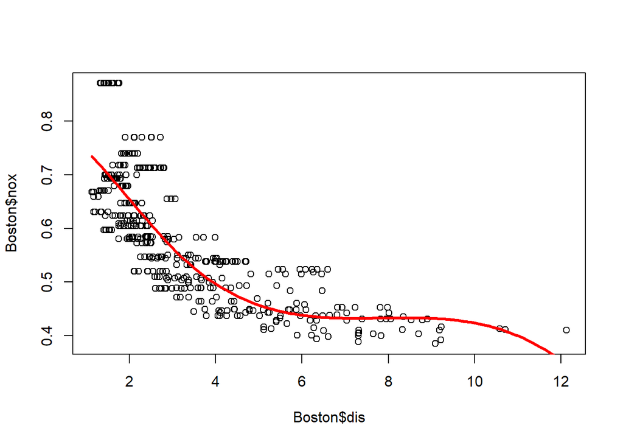

```r
plot(Boston$dis, Boston$nox)
lines(newdis, predict(fit1, newdata = list(dis=newdis)), col='red', lwd=3)
```

By the default setting of the `bs` function, the number of knots are determined once the `df` is specified, in this case, there is one knot.

### e

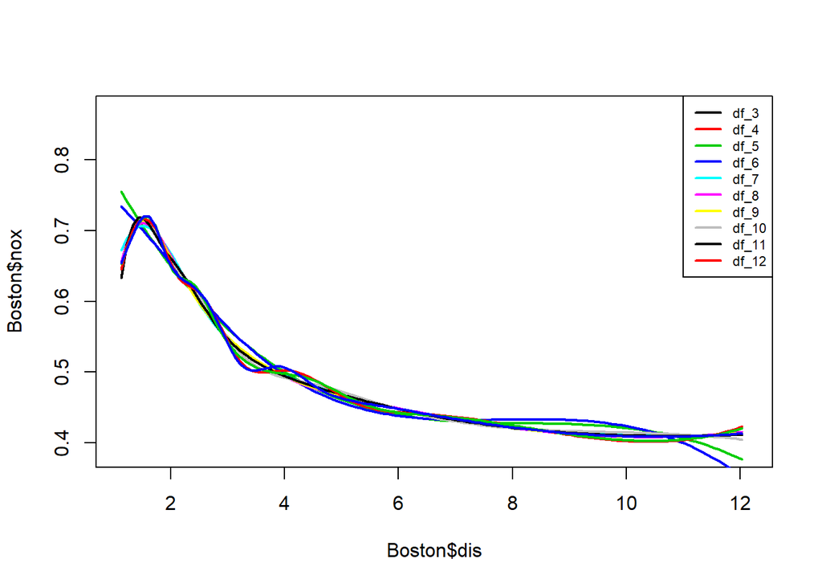

```r
f1=list()
rss1=c()
lgd1=c()
plot(Boston$dis,Boston$nox, col='white')
for (i in 3:12)
{
  f1[[i]]=glm(nox~bs(dis,df=i), data=Boston)
  rss1[i]=sum(f1[[i]]$residuals^2)
  lines(newdis, predict(f1[[i]], newdata = list(dis=newdis)),lwd=2, col=i)
  lgd1[i]=paste("df",i,sep="_")
}
legend('topright', lgd1[3:12], lwd=rep(2,10), col = c(1:10), cex=0.7)
```

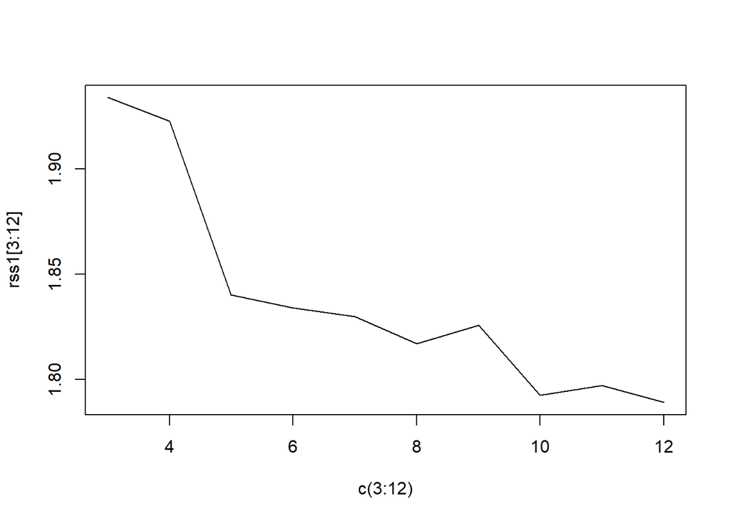

```r
plot(c(3:12),rss1[3:12], type = 'l')
```

### f

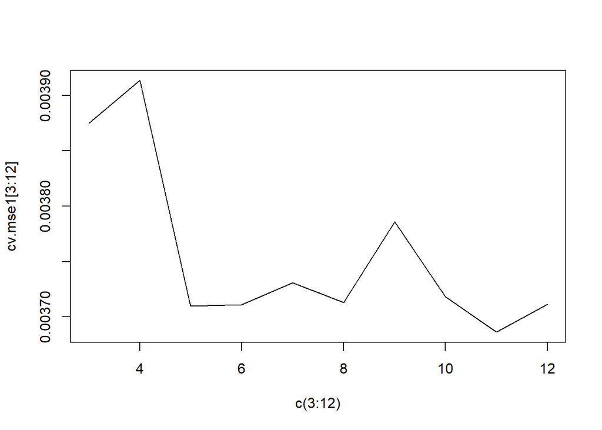

```r
set.seed(621)
cv.mse1=c()
for (i in 3:12)
{
  cv.mse1[i]=cv.glm(Boston, f1[[i]], K=10)$delta[1]
}
#warnings are due to different range of `dis` from training to testing sets during cv
plot(c(3:12),cv.mse1[3:12],type = 'l')
```

```r
match(min(cv.mse1,na.rm = T), cv.mse1)
```

```
## [1] 11
```

According to cross-validation $MSE$, the best degrees of freedom for a regression spline is $11$.

# ISLR Chapter 8

## 9

### a

```r
library(ISLR)
data(OJ)
set.seed(621)
splt=sample(1:nrow(OJ), 800)
OJ.trn=OJ[splt, ]
OJ.tst=OJ[-splt, ]
```

### b

```r
library(tree)
#no variable called `Buy`
tree1=tree(Purchase ~ ., data = OJ.trn)
summary(tree1)
```

```
##
## Classification tree:
## tree(formula = Purchase ~ ., data = OJ.trn)
## Variables actually used in tree construction:
## [1] "LoyalCH"        "PriceDiff"
## [3] "WeekofPurchase" "StoreID"
## Number of terminal nodes:  10
## Residual mean deviance:  0.7098 = 560.7 / 790
## Misclassification error rate: 0.1512 = 121 / 800
```

The training error rate is $0.1512$ and we have $10$ terminal nodes.

### c

```r
tree1
```

```
## node), split, n, deviance, yval, (yprob)
##       * denotes terminal node
##
##  1) root 800 1067.00 CH ( 0.61375 0.38625 )
##    2) LoyalCH < 0.48285 296  321.50 MM ( 0.23311 0.76689 )
##      4) LoyalCH < 0.0356415 54    0.00 MM ( 0.00000 1.00000 ) *
##      5) LoyalCH > 0.0356415 242  289.30 MM ( 0.28512 0.71488 )
##       10) PriceDiff < 0.05 102   85.18 MM ( 0.14706 0.85294 ) *
##       11) PriceDiff > 0.05 140  186.70 MM ( 0.38571 0.61429 )
##         22) LoyalCH < 0.136698 33   24.38 MM ( 0.12121 0.87879 ) *
##         23) LoyalCH > 0.136698 107  147.90 MM ( 0.46729 0.53271 )
##           46) WeekofPurchase < 247 41   47.69 MM ( 0.26829 0.73171 ) *
##           47) WeekofPurchase > 247 66   89.30 CH ( 0.59091 0.40909 ) *
##    3) LoyalCH > 0.48285 504  447.70 CH ( 0.83730 0.16270 )
##      6) LoyalCH < 0.764572 239  292.50 CH ( 0.69874 0.30126 )
##       12) PriceDiff < -0.165 38   43.80 MM ( 0.26316 0.73684 ) *
##       13) PriceDiff > -0.165 201  211.30 CH ( 0.78109 0.21891 )
##         26) PriceDiff < 0.265 111  138.40 CH ( 0.68468 0.31532 ) *
##         27) PriceDiff > 0.265 90   58.51 CH ( 0.90000 0.10000 ) *
##      7) LoyalCH > 0.764572 265   85.16 CH ( 0.96226 0.03774 )
##       14) StoreID < 5.5 150   73.48 CH ( 0.93333 0.06667 ) *
##       15) StoreID > 5.5 115    0.00 CH ( 1.00000 0.00000 ) *
```

Let’s pick the first terminal nodes: we split at `LoyalCH` $< 0.0356415$ and get $54$ observations that are classified as `MM`.

### d

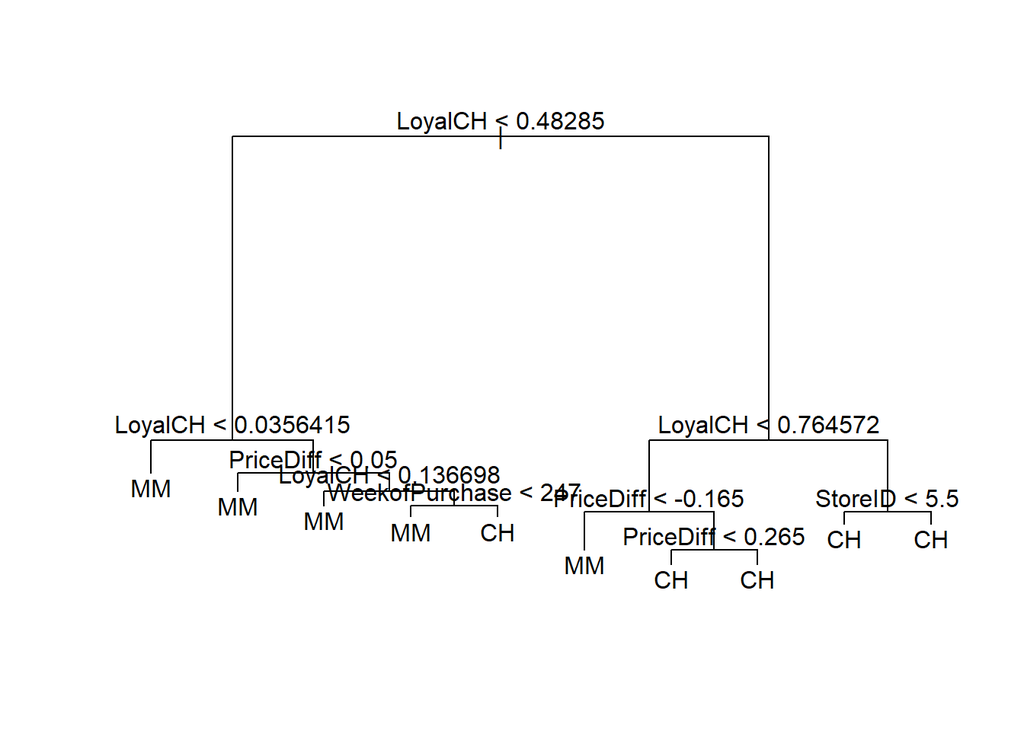

```r
plot(tree1)
text(tree1, pretty=0)
```

We can see that `LoyalCH` is the most important one for classification. The condition at each split indicates the branch on the left.

### e

```r
(cfmtrx=table(predict(tree1, OJ.tst, type = 'class'), OJ.tst$Purchase))
```

```
##
##       CH  MM
##   CH 147  39
##   MM  15  69
```

```r
(cfmtrx[2,1]+cfmtrx[1,2])/nrow(OJ.tst)
```

```
## [1] 0.2
```

### f

```r
set.seed(621)
OJ.cv=cv.tree(tree1, FUN=prune.tree)
```

### g

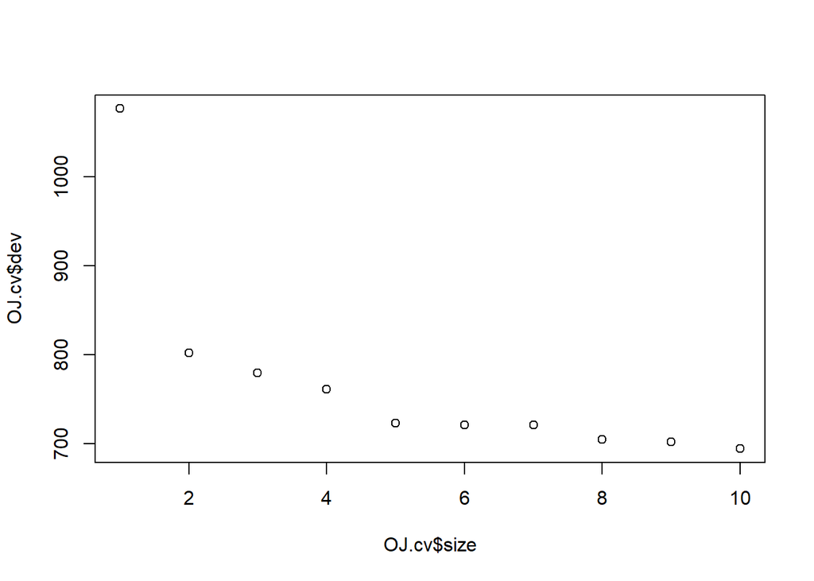

```r
plot(OJ.cv$size,OJ.cv$dev)
```

### h

It is still size of $10$ that gives the smallest cross-validation error rate.

### i

Since CV didn’t lead to selection of a pruned tree, we prune with five nodes.

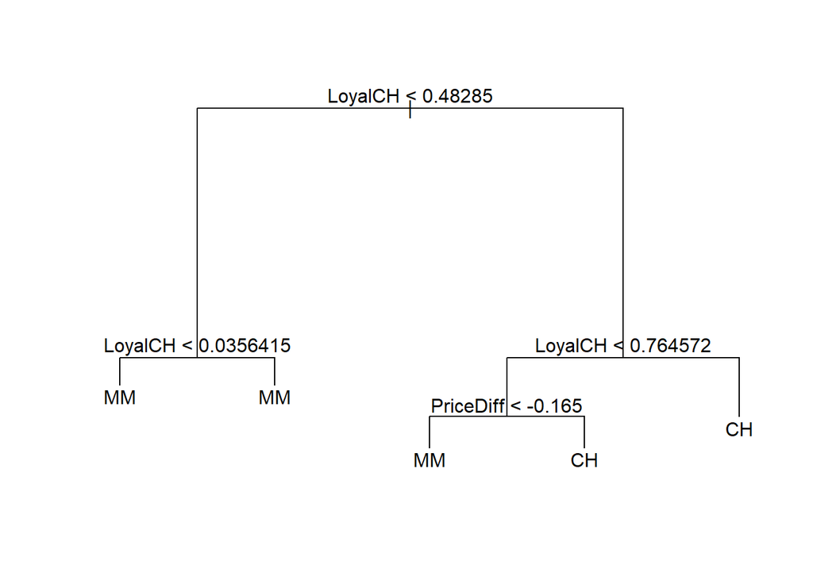

```r
tree1.prune=prune.tree(tree1, best = 5)
plot(tree1.prune)
text(tree1.prune, pretty = 0)
```

### j

```r
summary(tree1.prune)
```

```
##
## Classification tree:
## snip.tree(tree = tree1, nodes = c(7L, 13L, 5L))
## Variables actually used in tree construction:
## [1] "LoyalCH"   "PriceDiff"
## Number of terminal nodes:  5
## Residual mean deviance:  0.7919 = 629.5 / 795
## Misclassification error rate: 0.1662 = 133 / 800
```

The training error rate here is $0.1662$, which is higher than it is of unpruned tree.

### k

```r
(cfmtrx1=table(predict(tree1.prune, OJ.tst, type = 'class'), OJ.tst$Purchase))
```

```
##
##       CH  MM
##   CH 135  22
##   MM  27  86
```

```r
(cfmtrx1[2,1]+cfmtrx1[1,2])/nrow(OJ.tst)
```

```
## [1] 0.1814815
```

The test error rate here is $0.1814815$, a little improvement over the unpruned tree.

# ISLR Chapter 9

## 8

### a

Same as Q9 in Chapter 8.

### b

```r
library(e1071)
svm1=svm(Purchase ~ ., data = OJ.trn, kernel = "linear", cost = 0.01)
summary(svm1)
```

```
##
## Call:
## svm(formula = Purchase ~ ., data = OJ.trn,
##     kernel = "linear", cost = 0.01)
##
##
## Parameters:
##    SVM-Type:  C-classification
##  SVM-Kernel:  linear
##        cost:  0.01
##       gamma:  0.05555556
##
## Number of Support Vectors:  433
##
##  ( 215 218 )
##
##
## Number of Classes:  2
##
## Levels:
##  CH MM
```

With linear kernel at cost of $0.01$, we got $433$ upport vectors ($215$ for `CH`).

### c

```r
(cfmtrx2=table(svm1$fitted, OJ.trn$Purchase))
```

```
##
##       CH  MM
##   CH 439  77
##   MM  52 232
```

```r
(cfmtrx3=table(predict(svm1, OJ.tst), OJ.tst$Purchase))
```

```
##
##       CH  MM
##   CH 143  31
##   MM  19  77
```

```r
(cfmtrx2[2,1]+cfmtrx2[1,2])/nrow(OJ.trn)
```

```
## [1] 0.16125
```

```r
(cfmtrx3[2,1]+cfmtrx3[1,2])/nrow(OJ.tst)
```

```
## [1] 0.1851852
```

The training error rate is $0.16125$. The testing error rate is $0.1851852$.

### d

```r
set.seed(621)
svm1.tune=tune(svm, Purchase ~ ., data = OJ.trn, kernel = "linear", ranges = list(cost = seq(0.01,10,length.out = 20)))
summary(svm1.tune) #5.793684
```

```
##
## Parameter tuning of 'svm':
##
## - sampling method: 10-fold cross validation
##
## - best parameters:
##      cost
##  5.793684
##
## - best performance: 0.1625
##
## - Detailed performance results:
##          cost   error dispersion
## 1   0.0100000 0.16500 0.02813657
## 2   0.5357895 0.16750 0.03496029
## 3   1.0615789 0.16750 0.03184162
## 4   1.5873684 0.16750 0.03184162
## 5   2.1131579 0.17000 0.03016160
## 6   2.6389474 0.16750 0.02838231
## 7   3.1647368 0.16750 0.02838231
## 8   3.6905263 0.16625 0.03064696
## 9   4.2163158 0.16625 0.02889757
## 10  4.7421053 0.16500 0.02813657
## 11  5.2678947 0.16375 0.02791978
## 12  5.7936842 0.16250 0.03004626
## 13  6.3194737 0.16625 0.02889757
## 14  6.8452632 0.16625 0.02889757
## 15  7.3710526 0.16500 0.02813657
## 16  7.8968421 0.16625 0.02889757
## 17  8.4226316 0.16625 0.02889757
## 18  8.9484211 0.16625 0.02889757
## 19  9.4742105 0.16625 0.02889757
## 20 10.0000000 0.16625 0.02889757
```

### e

```r
svm1.best=svm(Purchase ~ ., data = OJ.trn, kernel = "linear", cost = 5.793684)
summary(svm1.best)
```

```
##
## Call:
## svm(formula = Purchase ~ ., data = OJ.trn,
##     kernel = "linear", cost = 5.793684)
##
##
## Parameters:
##    SVM-Type:  C-classification
##  SVM-Kernel:  linear
##        cost:  5.793684
##       gamma:  0.05555556
##
## Number of Support Vectors:  324
##
##  ( 162 162 )
##
##
## Number of Classes:  2
##
## Levels:
##  CH MM
```

```r
(cfmtrx4=table(svm1.best$fitted, OJ.trn$Purchase))
```

```
##
##       CH  MM
##   CH 439  73
##   MM  52 236
```

```r
(cfmtrx5=table(predict(svm1.best, OJ.tst), OJ.tst$Purchase))
```

```
##
##       CH  MM
##   CH 143  27
##   MM  19  81
```

```r
(cfmtrx4[2,1]+cfmtrx4[1,2])/nrow(OJ.trn)
```

```
## [1] 0.15625
```

```r
(cfmtrx5[2,1]+cfmtrx5[1,2])/nrow(OJ.tst)
```

```
## [1] 0.1703704
```

The optimal training error rate is $0.15625$. The testing error rate is $0.1703704$.

### f

```r
svm2=svm(Purchase ~ ., data = OJ.trn, kernel = "radial", cost = 0.01)
summary(svm2)
```

```
##
## Call:
## svm(formula = Purchase ~ ., data = OJ.trn,
##     kernel = "radial", cost = 0.01)
##
##
## Parameters:
##    SVM-Type:  C-classification
##  SVM-Kernel:  radial
##        cost:  0.01
##       gamma:  0.05555556
##
## Number of Support Vectors:  623
##
##  ( 314 309 )
##
##
## Number of Classes:  2
##
## Levels:
##  CH MM
```

```r
(cfmtrx6=table(svm2$fitted, OJ.trn$Purchase))
```

```
##
##       CH  MM
##   CH 491 309
##   MM   0   0
```

```r
(cfmtrx7=table(predict(svm2, OJ.tst), OJ.tst$Purchase))
```

```
##
##       CH  MM
##   CH 162 108
##   MM   0   0
```

```r
(cfmtrx6[2,1]+cfmtrx6[1,2])/nrow(OJ.trn)
```

```
## [1] 0.38625
```

```r
(cfmtrx7[2,1]+cfmtrx7[1,2])/nrow(OJ.tst)
```

```
## [1] 0.4
```

```r
#the classification at cost=0.01 is bad

set.seed(621)
svm2.tune=tune(svm, Purchase ~ ., data = OJ.trn, kernel = "radial", ranges = list(cost = seq(0.01,10,length.out = 20)))
summary(svm2.tune) #2.638947
```

```
##
## Parameter tuning of 'svm':
##
## - sampling method: 10-fold cross validation
##
## - best parameters:
##      cost
##  2.638947
##
## - best performance: 0.1725
##
## - Detailed performance results:
##          cost   error dispersion
## 1   0.0100000 0.38625 0.05219155
## 2   0.5357895 0.17375 0.02791978
## 3   1.0615789 0.17875 0.03438447
## 4   1.5873684 0.18000 0.03073181
## 5   2.1131579 0.17625 0.03408018
## 6   2.6389474 0.17250 0.03162278
## 7   3.1647368 0.17375 0.03653860
## 8   3.6905263 0.17625 0.03747684
## 9   4.2163158 0.17625 0.03972562
## 10  4.7421053 0.17375 0.04016027
## 11  5.2678947 0.17625 0.03928617
## 12  5.7936842 0.17750 0.03855011
## 13  6.3194737 0.17750 0.03855011
## 14  6.8452632 0.17750 0.03855011
## 15  7.3710526 0.17875 0.03910900
## 16  7.8968421 0.18000 0.03872983
## 17  8.4226316 0.18125 0.03644345
## 18  8.9484211 0.18125 0.03346329
## 19  9.4742105 0.18375 0.03175973
## 20 10.0000000 0.18375 0.03175973
```

```r
svm2.best=svm(Purchase ~ ., data = OJ.trn, kernel = "radial", cost = 2.638947)
summary(svm2.best)
```

```
##
## Call:
## svm(formula = Purchase ~ ., data = OJ.trn,
##     kernel = "radial", cost = 2.638947)
##
##
## Parameters:
##    SVM-Type:  C-classification
##  SVM-Kernel:  radial
##        cost:  2.638947
##       gamma:  0.05555556
##
## Number of Support Vectors:  346
##
##  ( 180 166 )
##
##
## Number of Classes:  2
##
## Levels:
##  CH MM
```

```r
(cfmtrx8=table(svm2.best$fitted, OJ.trn$Purchase))
```

```
##
##       CH  MM
##   CH 455  77
##   MM  36 232
```

```r
(cfmtrx9=table(predict(svm2.best, OJ.tst), OJ.tst$Purchase))
```

```
##
##       CH  MM
##   CH 145  30
##   MM  17  78
```

```r
(cfmtrx8[2,1]+cfmtrx8[1,2])/nrow(OJ.trn)
```

```
## [1] 0.14125
```

```r
(cfmtrx9[2,1]+cfmtrx9[1,2])/nrow(OJ.tst)
```

```
## [1] 0.1740741
```

The optimal training error rate for radial kernel is $0.14125$. The testing error rate is $0.1740741$.

### g

```r
svm3=svm(Purchase ~ ., data = OJ.trn, kernel = "polynomial", degree = 2, cost = 0.01)
summary(svm3)
```

```
##
## Call:
## svm(formula = Purchase ~ ., data = OJ.trn,
##     kernel = "polynomial", degree = 2, cost = 0.01)
##
##
## Parameters:
##    SVM-Type:  C-classification
##  SVM-Kernel:  polynomial
##        cost:  0.01
##      degree:  2
##       gamma:  0.05555556
##      coef.0:  0
##
## Number of Support Vectors:  625
##
##  ( 316 309 )
##
##
## Number of Classes:  2
##
## Levels:
##  CH MM
```

```r
(cfmtrx10=table(svm3$fitted, OJ.trn$Purchase))
```

```
##
##       CH  MM
##   CH 491 309
##   MM   0   0
```

```r
(cfmtrx11=table(predict(svm3, OJ.tst), OJ.tst$Purchase))
```

```
##
##       CH  MM
##   CH 162 108
##   MM   0   0
```

```r
(cfmtrx10[2,1]+cfmtrx10[1,2])/nrow(OJ.trn)
```

```
## [1] 0.38625
```

```r
(cfmtrx11[2,1]+cfmtrx11[1,2])/nrow(OJ.tst)
```

```
## [1] 0.4
```

```r
#similar as radial kernel, the performance of 2-degree-polynomial kernel at cost=0.01 is bad

set.seed(621)
svm3.tune=tune(svm, Purchase ~ ., data = OJ.trn, kernel = "polynomial", degree = 2, ranges = list(cost = seq(0.01,10,length.out = 20)))
summary(svm3.tune) #6.319474
```

```
##
## Parameter tuning of 'svm':
##
## - sampling method: 10-fold cross validation
##
## - best parameters:
##      cost
##  6.319474
##
## - best performance: 0.1575
##
## - Detailed performance results:
##          cost   error dispersion
## 1   0.0100000 0.38625 0.05219155
## 2   0.5357895 0.20375 0.03821086
## 3   1.0615789 0.18875 0.03928617
## 4   1.5873684 0.18750 0.04082483
## 5   2.1131579 0.18500 0.04518481
## 6   2.6389474 0.17625 0.04016027
## 7   3.1647368 0.17375 0.04348132
## 8   3.6905263 0.16875 0.04868051
## 9   4.2163158 0.16250 0.04859127
## 10  4.7421053 0.16250 0.04859127
## 11  5.2678947 0.16125 0.04980866
## 12  5.7936842 0.16125 0.04980866
## 13  6.3194737 0.15750 0.04571956
## 14  6.8452632 0.15875 0.04372023
## 15  7.3710526 0.16000 0.04479893
## 16  7.8968421 0.16000 0.04479893
## 17  8.4226316 0.16000 0.04479893
## 18  8.9484211 0.16125 0.04267529
## 19  9.4742105 0.16125 0.03972562
## 20 10.0000000 0.15750 0.04048319
```

```r
svm3.best=svm(Purchase ~ ., data = OJ.trn, kernel = "polynomial", degree = 2, cost = 6.319474)
summary(svm3.best)
```

```
##
## Call:
## svm(formula = Purchase ~ ., data = OJ.trn,
##     kernel = "polynomial", degree = 2, cost = 6.319474)
##
##
## Parameters:
##    SVM-Type:  C-classification
##  SVM-Kernel:  polynomial
##        cost:  6.319474
##      degree:  2
##       gamma:  0.05555556
##      coef.0:  0
##
## Number of Support Vectors:  348
##
##  ( 178 170 )
##
##
## Number of Classes:  2
##
## Levels:
##  CH MM
```

```r
(cfmtrx12=table(svm3.best$fitted, OJ.trn$Purchase))
```

```
##
##       CH  MM
##   CH 458  82
##   MM  33 227
```

```r
(cfmtrx13=table(predict(svm3.best, OJ.tst), OJ.tst$Purchase))
```

```
##
##       CH  MM
##   CH 145  36
##   MM  17  72
```

```r
(cfmtrx12[2,1]+cfmtrx12[1,2])/nrow(OJ.trn)
```

```
## [1] 0.14375
```

```r
(cfmtrx13[2,1]+cfmtrx13[1,2])/nrow(OJ.tst)
```

```
## [1] 0.1962963
```

The optimal training error rate for 2-degree-polynomial kernel is $0.14375$. The testing error rate is $0.1962963$.

### h

Overall, the linear and radial kernel performed almost equally well (linear with slightly better testing error and radial with better training error). Although the 2-degree-ploynomial kernel gives a good training error rate, its testing error rate is the worst.

# Boosting and Random Forest with `Khan` Dataset

## Boosting

```r
library(ISLR)
library(tidyverse)
library(xgboost)

data("Khan")
nm=c()
for (i in 1:ncol(Khan$xtrain))
{
  nm[i]=paste("G",i,sep="")
}

colnames(Khan$xtrain)=nm
colnames(Khan$xtest)=nm
dtrain=xgb.DMatrix(data = Khan$xtrain, label = Khan$ytrain-1)
dtest=xgb.DMatrix(data = Khan$xtest, label = Khan$ytest-1)

watchlist=list(train=dtrain, test=dtest)
xgb_params=list("objective" = "multi:softprob","num_class" = length(unique(Khan$ytrain)))
set.seed(621)
bst=xgb.train(params = xgb_params, data=dtrain,  max.depth=2, nthread = 1, eta=1, nround=10, watchlist=watchlist,eval.metric = "merror", eval.metric = "mlogloss")
#5 rounds are sufficient

pred=predict(bst, dtest)
test_prediction=matrix(pred, nrow = 4,ncol=length(pred)/4) %>%
  t() %>% data.frame() %>%
  mutate(label = Khan$ytest, max_prob = max.col(., "last"))
importance_matrix = xgb.importance(feature_names = nm, model = bst)
head(importance_matrix)
```

```
##    Feature       Gain      Cover Frequency
## 1:   G1389 0.26642427 0.08923869      0.04
## 2:   G1003 0.22835921 0.08923869      0.04
## 3:    G742 0.19080795 0.13517443      0.08
## 4:    G123 0.16460492 0.16336071      0.16
## 5:    G509 0.04700785 0.08254366      0.08
## 6:   G1954 0.03845944 0.06360466      0.08
```

```r
#linear
set.seed(621)
bst.l=xgb.train(params = xgb_params, data=dtrain,  max.depth=2, nthread = 1, booster='gblinear', nround=10, watchlist=watchlist,eval.metric = "merror", eval.metric = "mlogloss")
pred.l=predict(bst.l, dtest)
test_prediction.l=matrix(pred.l, nrow = 4,ncol=length(pred.l)/4) %>%
  t() %>% data.frame() %>%
  mutate(label = Khan$ytest, max_prob = max.col(., "last"))

library(caret)
#for tree boosting
confusionMatrix(factor(test_prediction$max_prob),factor(test_prediction$label),mode = "everything")
```

```
## Confusion Matrix and Statistics
##
##           Reference
## Prediction 1 2 3 4
##          1 2 0 0 0
##          2 0 6 0 0
##          3 1 0 6 0
##          4 0 0 0 5
##
## Overall Statistics
##
##                Accuracy : 0.95
##                  95% CI : (0.7513, 0.9987)
##     No Information Rate : 0.3
##     P-Value [Acc > NIR] : 1.662e-09
##
##                   Kappa : 0.9313
##  Mcnemar's Test P-Value : NA
##
## Statistics by Class:
##
##                      Class: 1 Class: 2 Class: 3
## Sensitivity            0.6667      1.0   1.0000
## Specificity            1.0000      1.0   0.9286
## Pos Pred Value         1.0000      1.0   0.8571
## Neg Pred Value         0.9444      1.0   1.0000
## Precision              1.0000      1.0   0.8571
## Recall                 0.6667      1.0   1.0000
## F1                     0.8000      1.0   0.9231
## Prevalence             0.1500      0.3   0.3000
## Detection Rate         0.1000      0.3   0.3000
## Detection Prevalence   0.1000      0.3   0.3500
## Balanced Accuracy      0.8333      1.0   0.9643
##                      Class: 4
## Sensitivity              1.00
## Specificity              1.00
## Pos Pred Value           1.00
## Neg Pred Value           1.00
## Precision                1.00
## Recall                   1.00
## F1                       1.00
## Prevalence               0.25
## Detection Rate           0.25
## Detection Prevalence     0.25
## Balanced Accuracy        1.00
```

```r
#for linear boosting
confusionMatrix(factor(test_prediction.l$max_prob),factor(test_prediction.l$label),mode = "everything")
```

```
## Confusion Matrix and Statistics
##
##           Reference
## Prediction 1 2 3 4
##          1 3 0 1 1
##          2 0 5 0 0
##          3 0 0 5 0
##          4 0 1 0 4
##
## Overall Statistics
##
##                Accuracy : 0.85
##                  95% CI : (0.6211, 0.9679)
##     No Information Rate : 0.3
##     P-Value [Acc > NIR] : 5.427e-07
##
##                   Kappa : 0.8
##  Mcnemar's Test P-Value : NA
##
## Statistics by Class:
##
##                      Class: 1 Class: 2 Class: 3
## Sensitivity            1.0000   0.8333   0.8333
## Specificity            0.8824   1.0000   1.0000
## Pos Pred Value         0.6000   1.0000   1.0000
## Neg Pred Value         1.0000   0.9333   0.9333
## Precision              0.6000   1.0000   1.0000
## Recall                 1.0000   0.8333   0.8333
## F1                     0.7500   0.9091   0.9091
## Prevalence             0.1500   0.3000   0.3000
## Detection Rate         0.1500   0.2500   0.2500
## Detection Prevalence   0.2500   0.2500   0.2500
## Balanced Accuracy      0.9412   0.9167   0.9167
##                      Class: 4
## Sensitivity            0.8000
## Specificity            0.9333
## Pos Pred Value         0.8000
## Neg Pred Value         0.9333
## Precision              0.8000
## Recall                 0.8000
## F1                     0.8000
## Prevalence             0.2500
## Detection Rate         0.2000
## Detection Prevalence   0.2500
## Balanced Accuracy      0.8667
```

Tree boosting is better.

## Random forest

```r
library(randomForest)

cntrl=trainControl(method="repeatedcv",number=5, repeats = 5, search="grid")
tunegrid=data.frame(.mtry=round(seq(40,100,length.out = 20)))

ptm <- proc.time()
fit.rf=train(x=Khan$xtrain,y=as.factor(Khan$ytrain), method="rf",trControl=cntrl,tuneGrid=tunegrid)
proc.time() - ptm
```

```
##    user  system elapsed
##  615.72    0.08  616.58
```

```r
print(fit.rf)
```

```
## Random Forest
##
##   63 samples
## 2308 predictors
##    4 classes: '1', '2', '3', '4'
##
## No pre-processing
## Resampling: Cross-Validated (5 fold, repeated 5 times)
## Summary of sample sizes: 50, 51, 50, 51, 50, 50, ...
## Resampling results across tuning parameters:
##
##   mtry  Accuracy   Kappa
##    40   0.9942857  0.9920000
##    43   1.0000000  1.0000000
##    46   0.9940659  0.9917864
##    49   0.9912088  0.9878152
##    53   0.9904296  0.9864205
##    56   0.9971429  0.9960839
##    59   0.9971429  0.9960839
##    62   0.9912088  0.9878703
##    65   0.9969231  0.9957025
##    68   1.0000000  1.0000000
##    72   0.9971429  0.9960284
##    75   1.0000000  1.0000000
##    78   1.0000000  1.0000000
##    81   1.0000000  1.0000000
##    84   0.9963636  0.9946341
##    87   1.0000000  1.0000000
##    91   1.0000000  1.0000000
##    94   1.0000000  1.0000000
##    97   0.9969231  0.9957724
##   100   1.0000000  1.0000000
##
## Accuracy was used to select the optimal
##  model using the largest value.
## The final value used for the model was mtry = 43.
```

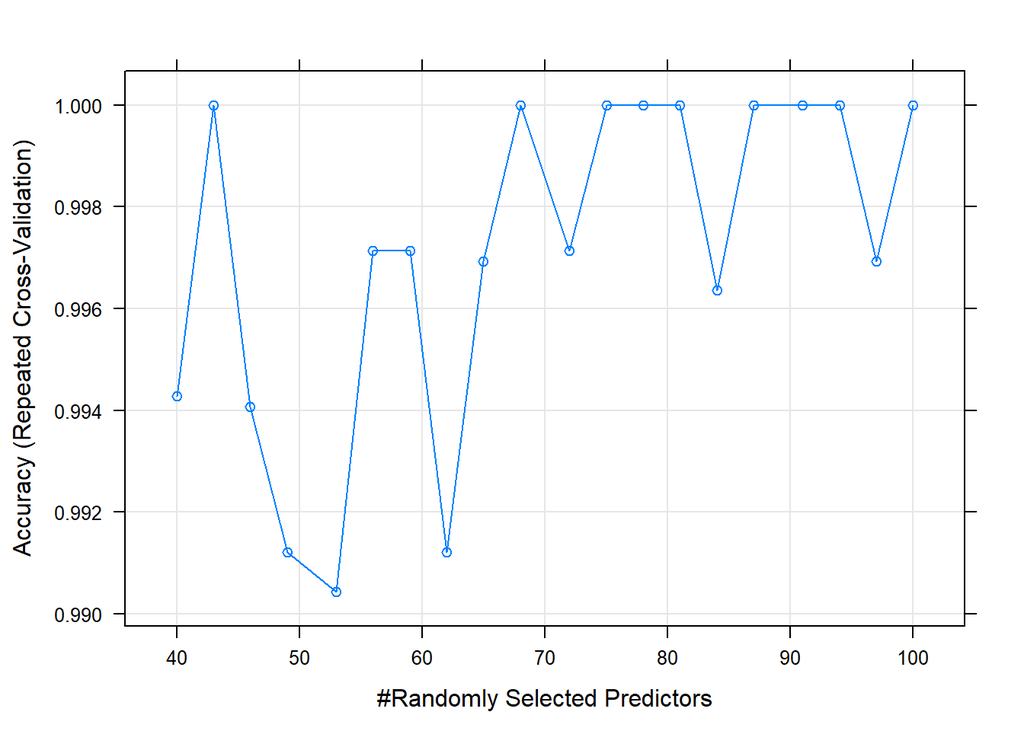

```r
plot(fit.rf)
```

```r
khantest=as.data.frame(cbind(Khan$xtest,as.factor(Khan$ytest)))
yhat.rf=predict(fit.rf, newdata = khantest)
confusionMatrix(data = yhat.rf, khantest$V2309)
```

```
## Confusion Matrix and Statistics
##
##           Reference
## Prediction 1 2 3 4
##          1 3 0 0 0
##          2 0 6 1 0
##          3 0 0 5 0
##          4 0 0 0 5
##
## Overall Statistics
##
##                Accuracy : 0.95
##                  95% CI : (0.7513, 0.9987)
##     No Information Rate : 0.3
##     P-Value [Acc > NIR] : 1.662e-09
##
##                   Kappa : 0.932
##  Mcnemar's Test P-Value : NA
##
## Statistics by Class:
##
##                      Class: 1 Class: 2 Class: 3
## Sensitivity              1.00   1.0000   0.8333
## Specificity              1.00   0.9286   1.0000
## Pos Pred Value           1.00   0.8571   1.0000
## Neg Pred Value           1.00   1.0000   0.9333
## Prevalence               0.15   0.3000   0.3000
## Detection Rate           0.15   0.3000   0.2500
## Detection Prevalence     0.15   0.3500   0.2500
## Balanced Accuracy        1.00   0.9643   0.9167
##                      Class: 4
## Sensitivity              1.00
## Specificity              1.00
## Pos Pred Value           1.00
## Neg Pred Value           1.00
## Prevalence               0.25
## Detection Rate           0.25
## Detection Prevalence     0.25
## Balanced Accuracy        1.00
```

```r
#variable importance
varImp(fit.rf, scale=FALSE)
```

```
## rf variable importance
##
##   only 20 most important variables shown (out of 2308)
##
##       Overall
## G2050  0.7727
## G1389  0.5946
## G1954  0.5659
## G545   0.5462
## G246   0.5304
## G1003  0.4771
## G1194  0.4722
## G1955  0.4568
## G1645  0.4170
## G1319  0.3887
## G1772  0.3807
## G129   0.3668
## G187   0.3486
## G107   0.3180
## G1723  0.3178
## G2046  0.3166
## G742   0.3028
## G1708  0.3010
## G1074  0.2928
## G554   0.2668
```

Both random forest and boosting performed well. But it took some time for random forest to find the optimal `mtry`. Linear boosting in this case didn’t out perform tree boosting, and tree boosting almost takes no time to run. So I would use tree boosting.